# Vers plus de reproductibilité ...

## Optionnel DQPRM 2016-2017

#### M. Bardiès, L. Ferrer, D. Sarrut

## Programme de la matinée

| Thème | Orateur | horaires |
| --- | --- | --- |
| Accueil | MB, LF, DS | 9:00-9:15 |
| Introduction, concepts généraux, Peer review | LF, DS | 9:15-09:45 |
| Table ronde | tous | 9:45-10:00 |
| Les outils: automatisation, scripting, *LP*<sup>1</sup> | LF | 10:00-10:30 |
| Les outils: *le contrôle de version* | DS | 10:30-11:00 |
| Retour d'experiences | LF, DS | 11:00-12:00 |

[1] LP : Litterate programming

## Programme de l'après-midi

| Thème | Orateur | horaires |
| --- | --- | --- |
| Création d'un rapport par LP | MB, LF, DS | 13:30-17:00 |

Le thème de cette journée est consacré à la mise en place d'une **démarche de qualité dans la gestion et le traitement des données pour assurer la reproductibilité des résultats** dans l'environnement d'un laboratoire de recherche ou d'un service de physique médicale.

Les étudiants devraient à la fin de cette journée avoir une idée plus précise des concepts fondamentaux pour développer des études scientifiques qui soient reproductibles par eux-mêmes ou bien d'autres personnes désirant vérifier/compléter le travail réalisé.

## Concepts généraux

### La réplication dans le domaine scientifique

La **réplication** est la pierre angulaire des découvertes scientifiques.

Si **vous** affirmez grâce à votre étude que X cause Y, alors **d'autres scientifiques** devraient refaire **la même étude** et devraient valider ou infirmer vos conclusions. Si beaucoup d'études similaires à la votre convergent vers les mêmes conclusions alors il y a une forte probabilité que vos résultats et conclusions soient correctes.

### La réplication dans le domaine scientifique

- **Pas toujours possible**,

Accidents nucléaires, catastrophes naturelles, etc ...

- **De plus en plus difficile à réaliser**,

[figure not shown]

  Etudes au long court (>20 ans), etc ...

### La réplication dans le domaine scientifique

[figure not shown]

y-a-t-il une alternative ?

## Réplication et reproductibilité

[figure not shown]

Roger D. Peng, *Reproducible Research in Computational Science*, Science, 02 dec 2011

## Réplication et reproductibilité

De Rokem, Marwick, & Staneva <sup>1</sup>:

> (Replicability) which refers to the ability of a researcher to **duplicate the results** of a prior study if the **same procedures** are followed but **new data** are collected.

<sup>1</sup> Kitzes, J., Turek, D., & Deniz, F. (Eds.). (2018). The Practice of Reproducible Research: Case Studies and Lessons from the Data-Intensive Sciences. Oakland, CA: University of California Press.

## Réplication et reproductibilité

De Stodden, Leisch & Peng <sup>1</sup>:

> Replication, the practice of independently implementing scientific experiments to validate specific findings, is the cornerstone of discovering scientific truth. <sup>1</sup> Victoria Stodden, Friedrich Leisch, Roger D. Peng *Implementing Reproducible science*, CRC Press, 14 avr. 2014 - 448 pages

## Réplication et reproductibilité

De Stodden, Leisch & Peng <sup>1</sup>:

> Related to replication is **reproducibility**, which is the calculation of quantitative scientific results by **independent scientists using the original datasets and methods**. Reproducibility can be thought of as a different standard of validity because it forgoes independent data collection and uses the methods and data collected by the original investigator. Reproducibility has become an important issue for more recent research due to advances in technology and the rapid spread of computational methods across the research landscape.

<sup>1</sup> Victoria Stodden, Friedrich Leisch, Roger D. Peng *Implementing Reproducible science*, CRC Press, 14 avr. 2014 - 448 pages

## La reproductibilité des résultats

- Rendre disponibles les **données analysées** et le **code d'analyse**
- D'autres personnes/équipes peuvent reproduire les résultats

**Attention**, cela n'assure pas que les conclusions des résultats soient justes.

Seul, une/des étude(s) **indépendante(s)** peut(vent) vérifier la justesse des conclusions de votre étude.

## Quelques contre-exemples récents

```python
from IPython.display import IFrame
#from IPython.core.display import
IFrame('http://www.nytimes.com/2013/04/19/opinion/krugman-the-excel-depression.html?_r=0',
       width=800,
       height=400)
```

[interactive chart not shown]

```python
from IPython.display import IFrame
#from IPython.core.display import
IFrame('http://www.nytimes.com/2013/04/19/opinion/krugman-the-excel-depression.html?_r=0',
       width=800, height=500)
```

[interactive chart not shown]

## La(es) méthodologie(s)

### Quelques principes généraux

1. Séparer, nommer et documenter **clairement** les données et fichiers et les actions opérant sur ces données et fichiers.
2. Documenter **exhaustivement** toutes les opérations, les **automatiser** le plus possible pour **éviter** les opérations manuelles.
3. Définir un **flux de travail** constitué de **petites séquences** liées entre-elles dont les **résultats intermédiaires** servent d'entrée à la suivante.

D'après *The practice of reproducible research*, Kitzes, J., Turek, D., & Deniz, F.

### Le flux de travail

La production d'un travail scientifique est le résultat d'un **enchainements de différentes tâches** :

- questionnement scientifique
- collecte des **données brutes**
- transformation des données
- calcul et analyse des résultats
- présentation des résultats (tableau, figures, ...)
- *écriture d'un document* (article, rapport de synthèse, ...)

[figure not shown]

D'après *Report writing for data science in R*, R. D. Peng, 2016

#### Première étape

- Créer une **structure de répertoires** adéquate à votre projet
- Associer des **métadonnées** à vos fichiers de données
- Ne pas modifier les données brutes.

[figure not shown]

D'après *The practice of reproducible research*, Kitzes, J., Turek, D., & Deniz, F.

#### La mise en forme des données

**Transformation des données**, data *wrangling/munging*

- récupérer un **sous-ensemble** des données
- supprimer les données invalides
- supprimer les données marginales
- etc ...

Eviter les manipulations manuelles, copier-coller, etc ...

**SCRIPTS**

Python, R, bash, perl, tcl, ...

[figure not shown]

D'après *The practice of reproducible research*, Kitzes, J., Turek, D., & Deniz, F.

## Les bonnes pratiques

### Pas de modifications manuelles

Ce qu'il ne faudrait pas faire **manuellement**:

- Editer des feuilles de calculs de tableurs pour nettoyer les données
  - enlever les données aberrantes
  - entrer des données à la main
- Editer des tables ou des figures (formatage)
- Télécharger des données sur le web à partir d'un navigateur web
- Déplacer les données dans d'autres répertoires
- Séparer, reformater les fichiers de données

### Pas de `pointer/cliquer`

- Eviter *si possible* les logiciels d'analyse comportant des interfaces graphiques.

ou alors

- Ecrire des procédures détaillées (modes opératoires)

### Apprendre à l'ordinateur à faire

Apprendre à un ordinateur à faire une tâche (même unique) est garant de reproductibilité (mais ne garantit pas contre les **erreurs**).

### Utiliser un gestionnaire de contrôle de version

Ces gestionnaires (git, SVN, CVS, mercurial) permettent de garder une **trace des modifications** faites sur des fichiers au cours du temps.

Par ailleurs, ils facilitent **le travail collaboratif** dans lequel l'échange de fichiers est une tâche fréquente entre les collaborateurs.

Ces systèmes permettent de s'assurer de disposer de la dernière version de travail du document ou de **gérer les conflits** en cas d'incohérence dans les versions du document échangé.

Plus à venir.

### Notifier votre espace numérique de travail

Il est important de garder une trace des informations des systèmes informatiques sur lesquels les données ont été générées et traitées. Par exemple,

| Elements | Type |
| --- | --- |
| architecture | Intel, ARM, AMD, GPUs... |
| système d'exploitation | Windows, Mac, Linux |
| chaine de traitement | compilateurs, interpreteur, shell (C, python, bash, ...) |
| infrastructure logicielle | bibliothèques et dépendances logicielles |
| dépendances externes | sites web, dépôts de données, bases de données externes, ... |
| versions | bibliothèques, logiciels, ... |

### Noter la graine

Les nombres pseudo-aléatoires sont utilisés dans de nombreux domaines scientifiques notamment par l'intermédiaire de méthodes telles que Monte-Carlo, Chaine de Markov, bootstrap, ...

Dès l'utilisation de ces nombres aléatoires, il faut penser à **spécifier** la graine utilisée par l'algorithme pseudo-aléatoires pour permettre de toujours obtenir le même résultat à chaque lancement du calcul.

#### Exemple

```python
import random
print([random.randint(0,10) for i in range(10)])
print([random.randint(0,10) for i in range(10)])
```

```
[6, 4, 8, 10, 2, 9, 8, 2, 5, 1]
[8, 6, 9, 8, 2, 2, 3, 1, 3, 5]
```

```python
random.seed(12345)
print([random.randint(0,10) for i in range(10)])
random.seed(12345)
print([random.randint(0,10) for i in range(10)])
```

```
[6, 0, 4, 5, 3, 4, 9, 6, 2, 5]
[6, 0, 4, 5, 3, 4, 9, 6, 2, 5]
```

### Enchainement des étapes

Les étapes de ce flux de traitements doivent respecter le plus possible les principes de reproductibilité car

> Une chaine est aussi solide que son maillon le plus faible.

On pourrait ajouter

> Le chemin pour arriver au but est aussi important que le but lui-même.

# Un exemple pratique avec Python.

### Enchainement des traitements

- Les données brutes de mesure sont enregistrées dans une structure de répertoires
- Nettoyer le fichier de données brutes et sauvegarder les données nettoyées dans un nouveau fichier
- Explorer/Analyser les données et stocker les résultats exploratoires dans un fichier au format texte ou `markdown`.

#### Lecture du fichier

```python
%matplotlib inline
import pandas
import matplotlib
import matplotlib.pyplot as plt

matplotlib.style.use('ggplot')

df = pandas.read_csv('../2017/ressources/monprojet/data_raw/raw_data.csv',
                     skipinitialspace=True)
print(df)
```

```
   obs1  obs2
0   1.5   3.2
1   1.9   4.5
2   1.4  10.0
3   2.1   NaN
4   1.3   2.5
5   1.6   3.1
```

#### Exploration des données

```python
print(df.describe())
```

```
           obs1       obs2
count  6.000000   5.000000
mean   1.633333   4.660000
std    0.307679   3.072946
min    1.300000   2.500000
25%    1.425000   3.100000
50%    1.550000   3.200000
75%    1.825000   4.500000
max    2.100000  10.000000
```

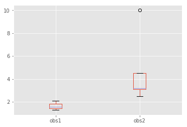

```python
df.boxplot();
```

#### Transformation des données

```python
# on supprime la ligne ne contenant pas de valeur
df.dropna(axis=0, inplace=True)
print(df.describe())
```

```
           obs1       obs2
count  5.000000   5.000000
mean   1.540000   4.660000
std    0.230217   3.072946
min    1.300000   2.500000
25%    1.400000   3.100000
50%    1.500000   3.200000
75%    1.600000   4.500000
max    1.900000  10.000000
```

```python
# il semble qu'une valeur aberrante se soit glissée dans le tableau
# on la supprime (ou bien on peut la remplacer par la moyenne des valeurs de la colonne)
df.drop(2, inplace=True)
print(df)
```

```
   obs1  obs2
0   1.5   3.2
1   1.9   4.5
4   1.3   2.5
5   1.6   3.1
```

#### Sauvegarde du nouveau fichier de travail

```python
# On écrit la version modifiée du fichier dans le répertoire
# prévu à cet effet.
df.to_csv('../2017/ressources/monprojet/data_clean/clean_data.csv')
```

On peut sauvegarder ces opérations dans un fichier `python` pour une utilisation ultérieure.

```python
%%file ./ressources/monprojet/src/traitement_raw.py
import pandas
# lecture du fichier brute
# On considère que les chemins d'accès des fichiers sont relatifs à mon projet
df = pandas.read_csv('./data_raw/raw_data.csv', skipinitialspace=True)
# on supprime la ligne ne contenant pas de valeur
df.dropna(axis=0, inplace=True)
# il semble qu'une valeur aberrante se soit glissée dans le tableau
# on la supprime (ou bien on peut la remplacer par la moyenne des valeurs de la colonne)
df.drop(2, inplace=True)
df.to_csv('./data_clean/clean_data.csv')
```

```
Overwriting ./ressources/monprojet/src/traitement_raw.py
```

```python
!tree ./ressources/monprojet/
```

```
./ressources/monprojet/
├── data_clean
│   └── clean_data.csv
├── data_raw
│   ├── README.txt
│   └── raw_data.csv
├── makefile
├── results
└── src
    ├── analyse.py
    └── traitement_raw.py

4 directories, 6 files
```

### L'analyse des données

On écrit un script `python` pour analyser les données et sauvegarder les résultats dans un fichier `markdown` par exemple.

Il faut commenter le code pour savoir ce qu'il fait.

```python
%%file ./ressources/monprojet/src/analyse.py
#--coding--: utf-8
'''
    ce script charge le fichier de données clean_data.csv
    qui contient les valeurs mesurées de 2 séries de mesures
    réalisées sur des appareils de mesures xxx et yyy.
    On réalise un test de Student sur les 2 series de mesures
    pour vérifier si les moyennes sont significativement différentes.

    Un fichier image contenant des boites à moustache est aussi sauvegardé.
'''
import matplotlib.pyplot as plt
import pandas
import scipy
import scipy.stats as st
# Lecture du fichier de données
df_test = pandas.read_csv('./ressources/monprojet/data_clean/clean_data.csv',
                                  skipinitialspace=True)
# test de student symetrique sur les 2 échantillons
test_statisique = st.ttest_ind(df_test.obs1,df_test.obs2)
# on crée et sauvegarde un graphique
plt.figure()
df_test.boxplot(column=['obs1','obs2'])
plt.title('test de Student')
plt.savefig('./ressources/monprojet/results/boxplot_obs1_obs2.png')
# Ecriture d'un fichier mardown dans le repertoire results
with open('./ressources/monprojet/results/rapport.md', 'w') as f_out:
    f_out.write('# Rapport de sortie\n')
    f_out.write('----\n\n')
    f_out.write('outils utilisés\n\n')
    f_out.write('la version de pandas: {}\n\n'.format(pandas.__version__))
    f_out.write('la version de scipy: {}\n\n'.format(scipy.__version__))
    f_out.write('----\n\n')
    f_out.write('Le résultat du test de student est: {:.3f}\n\n'.format(test_statisique.statistic))
    f_out.write('la p-value est: {:.3f}\n\n'.format(test_statisique.pvalue))
    f_out.write('Le graphique suivant montre **les boites à moustache**.\n\n')
    f_out.write("!['image de la boxplot'](./boxplot_obs1_obs2.png)")
print('le résultat du test de student est: {:.3f}'.\
      format(test_statisique.statistic))
print('la p-value est: {:.3f}'.format(test_statisique.pvalue))
```

```
Overwriting ./ressources/monprojet/src/analyse.py
```

On lance d'execution du script.

```
le résultat du test de student est: -3.984
la p-value est: 0.007
```

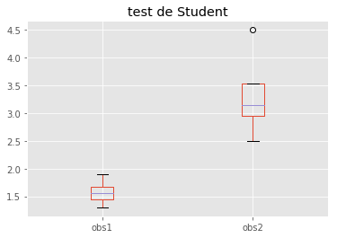

```python
%run ./ressources/monprojet/src/analyse.py
```

Un coup d'oeil sur les fichiers contenus dans les répertoires.

```python
!tree ./ressources/monprojet/
```

```
./ressources/monprojet/
├── data_clean
│   └── clean_data.csv
├── data_raw
│   ├── README.txt
│   └── raw_data.csv
├── makefile
├── results
│   ├── boxplot_obs1_obs2.png
│   └── rapport.md
└── src
    ├── analyse.py
    └── traitement_raw.py

4 directories, 8 files
```

### La diffusion du rapport

On a crée un fichier au format `markdown` mais on peut aussi le transformer pour créer un fichier au format `pdf` ou `html`.

Il faut donc utiliser un outil de transformation `markdown` $\rightarrow$ `html`.

On peut utiliser `pandoc` par exemple.

```
pandoc -r markdown -t html ./results/rapport.md -s\
     -o ./results/rapport.html --data-dir='./results'
```

Pour être sûr de ne pas oublier les étapes, on peut créer un script qui lance l'ensemble des opérations.

On peut aussi utiliser **avantageusement** un outil comme `make` ou `cmake` qui ne lance les opérations que si l'un des fichiers a été modifié.

```
all:    report_html

report_html:    analyse
    pandoc -r markdown -t html ./results/rapport.md -s\
     -o ./results/rapport.html --data-dir='./results'

analyse:    munge
    python ./src/analyse.py

munge:
    python ./src/traitement_raw.py

clean:
    rm -f ./results/*
    rm -f ./data_clean/*
```